# WeatherCurrencyAndSales

Caroline Silvestre

30/09/2018

```r
#clean up env
rm(list = ls())

library(readr)
library(stats)
library(dplyr)
library(reshape2)
library(lubridate)
```

```r
library(ggplot2)
library(forecast)
library(BBmisc)
library(zoo)
#read data from csv and loading sales data with dates and formatting the date field as date in R
#Note: file must be a csv and the date order must be oldest to newest in the file.
SalesData <-  as.data.frame(read_csv("SalesReportDaily.csv"))
```

```
##       Date            Daily_Items_Sold  Transactions   Total_Daily_Value
##  Min.   :2014-01-01   Min.   : 122     Min.   : 52.0   Min.   :  5335
##  1st Qu.:2015-03-06   1st Qu.: 385     1st Qu.:151.0   1st Qu.: 17310
##  Median :2016-05-08   Median :1122     Median :431.0   Median : 56098
##  Mean   :2016-05-08   Mean   :1191     Mean   :438.6   Mean   : 61403
##  3rd Qu.:2017-07-11   3rd Qu.:1805     3rd Qu.:696.0   3rd Qu.: 95173
##  Max.   :2018-09-13   Max.   :4270     Max.   :998.0   Max.   :225128
##                                        NA's   :130
##  Avg_Item_Value_GBP Avg_Trans_Value_GBP
##  Min.   :29.70      Min.   : 73.14
##  1st Qu.:45.85      1st Qu.:109.26
##  Median :49.72      Median :119.30
##  Mean   :49.17      Mean   :118.33
##  3rd Qu.:52.69      3rd Qu.:127.90
##  Max.   :62.64      Max.   :154.06
##
```

```r
require(lubridate)
date <- ymd(SalesData$Date)
SalesData$Date <- date
SalesData$DoW <- as.factor(weekdays.Date(date))
SalesData$WeekNum <- recode(SalesData$DoW,'Monday'=1,'Tuesday'=2, 'Wednesday'=3,'Thursday'=4,
                                        'Friday'=5,'Saturday'=6,'Sunday'=7)
### add the number of the month
require("lubridate")
SalesData$MonthNum <- month(SalesData$Date)
SalesData$MonthFactor <- as.factor(recode(SalesData$MonthNum, '1'="Jan", '2'= "Feb", '3'= "Mar", '4'= "Apr", '5'= "May", '6'= "Jun", '7'="Jul",'8' = "Aug", '9'= "Sep", '10' = "Oct", '11'= "Nov", '12' = "Dec"))

#setting the seasonality variables
weekly <- 7
monthly <- 30.5
yearly <- 364.25

#adding a normalized version of daily sales values to the dataframe, using a 1 to 10 range to avoid zero values
SalesData$ValNorm <- normalize(SalesData$Total_Daily_Value , method="range", range=c(1,10))

#need to transform sales data into ts (time series) objects and then into a msts (multi-seasonal time-series). The default is daily.
#function to transform a vector into a time series object. Need the day of the year as a number from 1 to 365/366.
#freq is the data interval, for daily data use yearly.

ts.transform <- function(univariateseries, YYYY,DDD, freq){
  x = ts(univariateseries, start = c(YYYY,DDD) , frequency = freq)
  return(x)
}

tsVal <- ts.transform(SalesData$Total_Daily_Value, 2014,001, yearly)
```

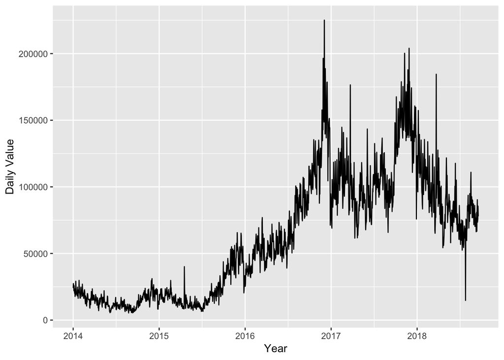

```r
#time series for all variables were created, but they were not used this time
tsItems <- ts.transform(SalesData$Daily_Items_Sold, 2014,001, yearly)
#autoplot.zoo(tsItems) + ylab("Daily Items") + xlab("Year")

tsATV <- ts.transform(SalesData$Avg_Trans_Value_GBP, 2014,001, yearly)
#autoplot.zoo(tsATV) + ylab("Daily Items") + xlab("Year")

tsValNorm <- ts.transform(SalesData$ValNorm,2014,001, yearly)
#autoplot(tsValNorm) + ylab("Sales Volume Normalised") + xlab("Year")

#function for transforming a time series object into a msts, which is a multiple-series time series
require(forecast)
msts.transform <- function(tsobj, YYYY,DDD,s1=NULL,s2=NULL,s3=NULL){
  a = msts(tsobj, start = c(2014,001), seasonal.periods=c(s1,s2,s3))
  return(a)
}

#function to decompose both single-seasonal and multi-seasonal time-series
decomp.msts <- function(mstsobj){
  xy1 = mstl(mstsobj, iterate = 3)
  return(xy1)
}

#By default the Full Daily Sales Value will be used for ease of visualisation, with yearly and weekly pattern, but only normlised plots will be generated for better visualisation
mstsVal <- msts.transform(tsVal, 2014,001, weekly, yearly)
decVals <- decomp.msts(mstsVal)
```

```r
#generating a decomposition of the normalised Daily sales values for use in the analysis in conjunction with other variables.
salesNormmsts_mwy <- msts(tsValNorm, seasonal.periods=c(7,30.5,365.25))
xnorm_wmy <- mstl(salesNormmsts_mwy, lambda = "auto", iterate = 3)

#generating a dataset with decomposed values to use with GAM
dat_decomp <- as.data.frame(xnorm_wmy)
dat_decomp$Date <- date

#mergin the decomposition to the original data frame
SalesData<- merge(SalesData, dat_decomp, by.x = "Date", by.y = "Date", all.x = TRUE)
```

Decomposition of Daily Sales data into five elements: - Trend - Weekly seasonality (7 day period) - Monthly seasonality (30.5 day period) - Yearly seasonality (365.25 day period)

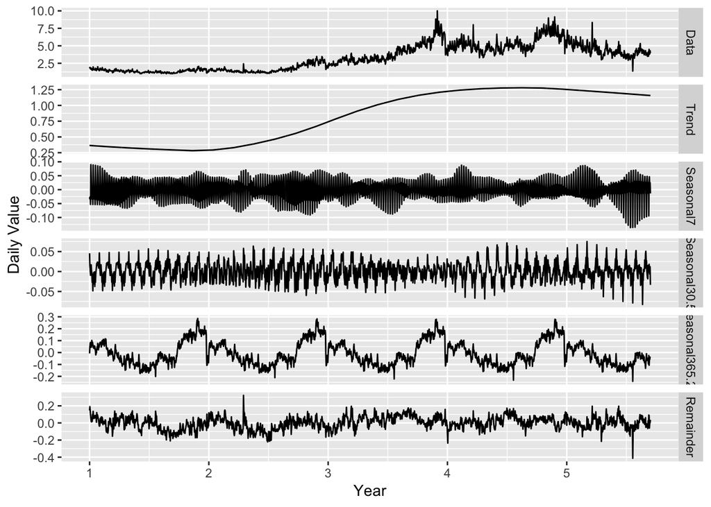

Notes on forecasting based on sales data and seasonality only

When x is a msts object, K should be a vector of integers specifying the number of sine and cosine (Fourier) terms for each of the seasonal periods. Therefore, the best way to find a suitable number of Fourier terms, it is advisable to do it by computing the lowest AICc. However, due to the large amount of data, the code to make this calculation takes several minutes to run (over 30 minutes). The code below had been added for reference, but it will not be run and forecast using ARIMA with fourier terms will be replaced by Generalized additive models instead (GAM).

```r
#salesmsts = msts(timeseriesValue, start = c(2014,001), seasonal.periods=c(365.25))
#bestfit <- list(aicc=Inf)
#for(K in seq(25)) {
 # fit <- auto.arima(salesmsts, xreg=fourier(salesmsts, K=K),
  #                  seasonal=FALSE)
  #if(fit[["aicc"]] < bestfit[["aicc"]]) {
   # bestfit <- fit
    #bestK <- K
  #}
#}
#fc <- forecast(bestfit,
 #              xreg=fourier(salesmsts, K=bestK, h=6*365.25))

#autoplot(fc)

#fit[["aicc"]]

#arima fcast with week and year seasonalities, for future comparison with GAM models
#the value of K = 19 was found by running a script for a few hours, based on the lowest AIcc
#The code below retunrs forecasting using a dynamic regression for 90 days ahead
#the code below takes several minutes to run

#for predicting sales using the arima decomposition only for comparison to the gam
#fitwy <- auto.arima(mstsVal, seasonal=FALSE,
                      #xreg=fourier(mstsVal, K=c(3,19)))
#fitwy %>% forecast(xreg=fourier(salesmsts, K=c(3,19), h=1*90)) %>% autoplot(include=6*336)'
```

Joining historical values for both weather observations and currency exchange on date.

```r
WeatherData <- read_csv("WeatherDaily.csv")
weatherdates <- as.Date(WeatherData$DATE, "%d/%m/%Y")
#View(weatherdates)
WeatherData$DATE <- weatherdates
#remove NA's
WeatherData$PRCP[is.na(WeatherData$PRCP)] <- 0

#uploading currency data
CurrencyData <- CurrencyExchangeDaily <- read_csv("CurrencyExchangeDaily.csv")
currencydates <- mdy(CurrencyData$Date)
CurrencyData$Date <- currencydates
#trading stops on weekends, so weekends will carry the latest value after the merge of datasets

#removing data we don't need
CurrencyData$Open <- NULL
CurrencyData$High <- NULL
CurrencyData$Low <- NULL
CurrencyData$Change <- NULL


#merging weather and sales dataframes
newdf <- merge(SalesData, WeatherData, by.x = "Date", by.y = "DATE", all.x = TRUE)
#adding currency data
newdf <- merge(newdf, CurrencyData, by.x = "Date", by.y = "Date", all.x = TRUE)
#replacing NA's in currency data with the last value
newdf$Price <- na.locf(newdf$Price)

#transforming precipitation into factors - 'rain' and 'dry'
newdf$PrecFact <- newdf$PRCP[newdf$PRCP > 0] <- 1
newdf$PrecFact <- as.factor(newdf$PRCP)

#running a seasonal decomposition on weather as it is a highly seasonal feature
tavg.ts <- ts(newdf$TAVG)
tavg.msts <- msts.transform(tavg.ts,2014,001,yearly)
tavg.decomp <- decomp.msts(tavg.msts)


summary(newdf)
```

```
##       Date            Daily_Items_Sold  Transactions   Total_Daily_Value
##  Min.   :2014-01-01   Min.   : 122     Min.   : 52.0   Min.   :  5335
##  1st Qu.:2015-03-06   1st Qu.: 385     1st Qu.:151.0   1st Qu.: 17310
##  Median :2016-05-08   Median :1122     Median :431.0   Median : 56098
##  Mean   :2016-05-08   Mean   :1191     Mean   :438.6   Mean   : 61403
##  3rd Qu.:2017-07-11   3rd Qu.:1805     3rd Qu.:696.0   3rd Qu.: 95173
##  Max.   :2018-09-13   Max.   :4270     Max.   :998.0   Max.   :225128
##                                        NA's   :130
##  Avg_Item_Value_GBP Avg_Trans_Value_GBP        DoW         WeekNum
##  Min.   :29.70      Min.   : 73.14      Friday   :245   Min.   :1.000
##  1st Qu.:45.85      1st Qu.:109.26      Monday   :245   1st Qu.:2.000
##  Median :49.72      Median :119.30      Saturday :245   Median :4.000
##  Mean   :49.17      Mean   :118.33      Sunday   :245   Mean   :3.999
##  3rd Qu.:52.69      3rd Qu.:127.90      Thursday :246   3rd Qu.:6.000
##  Max.   :62.64      Max.   :154.06      Tuesday  :245   Max.   :7.000
##                                         Wednesday:246
##     MonthNum       MonthFactor     ValNorm            Data
##  Min.   : 1.000   Aug    :155   Min.   : 1.000   Min.   : 1.000
##  1st Qu.: 3.000   Jan    :155   1st Qu.: 1.490   1st Qu.: 1.490
##  Median : 6.000   Jul    :155   Median : 3.079   Median : 3.079
##  Mean   : 6.259   Mar    :155   Mean   : 3.296   Mean   : 3.296
##  3rd Qu.: 9.000   May    :155   3rd Qu.: 4.679   3rd Qu.: 4.679
##  Max.   :12.000   Apr    :150   Max.   :10.000   Max.   :10.000
##                   (Other):792
##      Trend          Seasonal7           Seasonal30.5
##  Min.   :0.2821   Min.   :-1.362e-01   Min.   :-8.251e-02
##  1st Qu.:0.3524   1st Qu.:-2.177e-02   1st Qu.:-1.654e-02
##  Median :0.9730   Median :-3.098e-03   Median : 1.573e-04
##  Mean   :0.8335   Mean   :-1.859e-05   Mean   : 1.566e-05
##  3rd Qu.:1.2271   3rd Qu.: 2.618e-02   3rd Qu.: 1.507e-02
##  Max.   :1.2805   Max.   : 8.974e-02   Max.   : 7.506e-02
##
##  Seasonal365.25        Remainder               PRCP            TAVG
##  Min.   :-0.242018   Min.   :-0.4126526   Min.   :0.000   Min.   :-4.10
##  1st Qu.:-0.087261   1st Qu.:-0.0475279   1st Qu.:0.000   1st Qu.: 7.90
##  Median :-0.026695   Median : 0.0043379   Median :0.000   Median :12.10
##  Mean   :-0.006629   Mean   : 0.0003003   Mean   :0.446   Mean   :12.11
##  3rd Qu.: 0.065400   3rd Qu.: 0.0516012   3rd Qu.:1.000   3rd Qu.:16.40
##  Max.   : 0.286105   Max.   : 0.3221262   Max.   :1.000   Max.   :27.90
##                                           NA's   :4       NA's   :4
##      Price         Change %         PrecFact
##  Min.   :1.205   Length:1717        0   :949
##  1st Qu.:1.311   Class :character   1   :764
##  Median :1.425   Mode  :character   NA's:  4
##  Mean   :1.440
##  3rd Qu.:1.556
##  Max.   :1.717
##
```

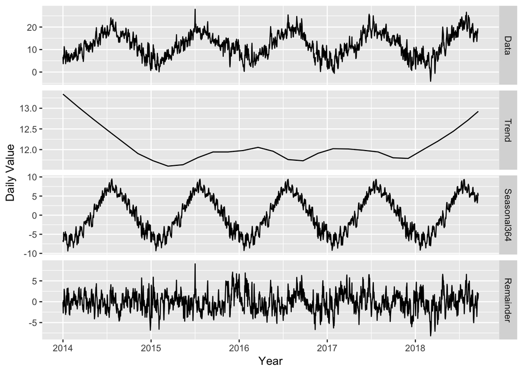

Because weather is seasonal as well as sales, decomposing the seasonality from the weather and using the remainder element of decomposition seemed like the best way of retrieving ‘unusually’ cold or hot days for use in the analysis, instead of actual values. This is because the peak of sales is on the runup to the Chrstmas period, which coincides with the colder months in the nothern hemisphere. If this same analysis were run on the southern hemispehere, there is a change that the results would be completely different.

```r
Temperature  <- as.data.frame(tavg.decomp)
Temperature$Date <- newdf$Date
#merge datasets again
newdf <- merge(newdf, Temperature, by.x = "Date", by.y = "Date", all.x = TRUE )

#change days of week and month as factors
newdf$DoW <- as.factor(newdf$DoW)
newdf$MonthFactor <- as.factor(newdf$MonthFactor)
```

The merging of all data that has been extracted, manipulated or kept as original, has resulted in a large dataset. From those resulting variables, different models will be tested for accuracy of forecast.

```r
summary(newdf)
```

```
##       Date            Daily_Items_Sold  Transactions   Total_Daily_Value
##  Min.   :2014-01-01   Min.   : 122     Min.   : 52.0   Min.   :  5335
##  1st Qu.:2015-03-06   1st Qu.: 385     1st Qu.:151.0   1st Qu.: 17310
##  Median :2016-05-08   Median :1122     Median :431.0   Median : 56098
##  Mean   :2016-05-08   Mean   :1191     Mean   :438.6   Mean   : 61403
##  3rd Qu.:2017-07-11   3rd Qu.:1805     3rd Qu.:696.0   3rd Qu.: 95173
##  Max.   :2018-09-13   Max.   :4270     Max.   :998.0   Max.   :225128
##                                        NA's   :130
##  Avg_Item_Value_GBP Avg_Trans_Value_GBP        DoW         WeekNum
##  Min.   :29.70      Min.   : 73.14      Friday   :245   Min.   :1.000
##  1st Qu.:45.85      1st Qu.:109.26      Monday   :245   1st Qu.:2.000
##  Median :49.72      Median :119.30      Saturday :245   Median :4.000
##  Mean   :49.17      Mean   :118.33      Sunday   :245   Mean   :3.999
##  3rd Qu.:52.69      3rd Qu.:127.90      Thursday :246   3rd Qu.:6.000
##  Max.   :62.64      Max.   :154.06      Tuesday  :245   Max.   :7.000
##                                         Wednesday:246
##     MonthNum       MonthFactor     ValNorm           Data.x
##  Min.   : 1.000   Aug    :155   Min.   : 1.000   Min.   : 1.000
##  1st Qu.: 3.000   Jan    :155   1st Qu.: 1.490   1st Qu.: 1.490
##  Median : 6.000   Jul    :155   Median : 3.079   Median : 3.079
##  Mean   : 6.259   Mar    :155   Mean   : 3.296   Mean   : 3.296
##  3rd Qu.: 9.000   May    :155   3rd Qu.: 4.679   3rd Qu.: 4.679
##  Max.   :12.000   Apr    :150   Max.   :10.000   Max.   :10.000
##                   (Other):792
##     Trend.x         Seasonal7           Seasonal30.5
##  Min.   :0.2821   Min.   :-1.362e-01   Min.   :-8.251e-02
##  1st Qu.:0.3524   1st Qu.:-2.177e-02   1st Qu.:-1.654e-02
##  Median :0.9730   Median :-3.098e-03   Median : 1.573e-04
##  Mean   :0.8335   Mean   :-1.859e-05   Mean   : 1.566e-05
##  3rd Qu.:1.2271   3rd Qu.: 2.618e-02   3rd Qu.: 1.507e-02
##  Max.   :1.2805   Max.   : 8.974e-02   Max.   : 7.506e-02
##
##  Seasonal365.25       Remainder.x              PRCP            TAVG
##  Min.   :-0.242018   Min.   :-0.4126526   Min.   :0.000   Min.   :-4.10
##  1st Qu.:-0.087261   1st Qu.:-0.0475279   1st Qu.:0.000   1st Qu.: 7.90
##  Median :-0.026695   Median : 0.0043379   Median :0.000   Median :12.10
##  Mean   :-0.006629   Mean   : 0.0003003   Mean   :0.446   Mean   :12.11
##  3rd Qu.: 0.065400   3rd Qu.: 0.0516012   3rd Qu.:1.000   3rd Qu.:16.40
##  Max.   : 0.286105   Max.   : 0.3221262   Max.   :1.000   Max.   :27.90
##                                           NA's   :4       NA's   :4
##      Price         Change %         PrecFact       Data.y
##  Min.   :1.205   Length:1717        0   :949   Min.   :-4.10
##  1st Qu.:1.311   Class :character   1   :764   1st Qu.: 7.90
##  Median :1.425   Mode  :character   NA's:  4   Median :12.10
##  Mean   :1.440                                 Mean   :12.11
##  3rd Qu.:1.556                                 3rd Qu.:16.40
##  Max.   :1.717                                 Max.   :27.90
##                                                NA's   :4
##     Trend.y       Seasonal364        Remainder.y
##  Min.   :11.60   Min.   :-9.37370   Min.   :-8.19060
##  1st Qu.:11.83   1st Qu.:-4.31523   1st Qu.:-1.66520
##  Median :11.97   Median :-0.26674   Median :-0.08504
##  Mean   :12.08   Mean   : 0.07863   Mean   :-0.04054
##  3rd Qu.:12.17   3rd Qu.: 4.68471   3rd Qu.: 1.44230
##  Max.   :13.34   Max.   : 9.46271   Max.   : 9.07603
##
```

Part 2 - Determining variable correlation using Generalized additive models with integrated smoothness estimation.

```r
library(mgcv)
#reading dataframe as data.table
DT <- as.data.frame.table(newdf)
summary(DT)
```

```
##       Var1                        Var2         Freq.Date
##  1      :   26   Date               : 1717   Min.   :2014-01-01
##  2      :   26   Daily_Items_Sold   : 1717   1st Qu.:2015-03-06
##  3      :   26   Transactions       : 1717   Median :2016-05-08
##  4      :   26   Total_Daily_Value  : 1717   Mean   :2016-05-08
##  5      :   26   Avg_Item_Value_GBP : 1717   3rd Qu.:2017-07-11
##  6      :   26   Avg_Trans_Value_GBP: 1717   Max.   :2018-09-13
##  (Other):44486   (Other)            :34340
##  Freq.Daily_Items_Sold Freq.Transactions Freq.Total_Daily_Value
##  Min.   : 122          Min.   : 52.0     Min.   :  5335
##  1st Qu.: 385          1st Qu.:151.0     1st Qu.: 17310
##  Median :1122          Median :431.0     Median : 56098
##  Mean   :1191          Mean   :438.6     Mean   : 61403
##  3rd Qu.:1805          3rd Qu.:696.0     3rd Qu.: 95173
##  Max.   :4270          Max.   :998.0     Max.   :225128
##                        NA's   :3380
##  Freq.Avg_Item_Value_GBP Freq.Avg_Trans_Value_GBP      Freq.DoW
##  Min.   :29.70           Min.   : 73.14           Friday   :6370
##  1st Qu.:45.85           1st Qu.:109.26           Monday   :6370
##  Median :49.72           Median :119.30           Saturday :6370
##  Mean   :49.17           Mean   :118.33           Sunday   :6370
##  3rd Qu.:52.69           3rd Qu.:127.90           Thursday :6396
##  Max.   :62.64           Max.   :154.06           Tuesday  :6370
##                                                   Wednesday:6396
##   Freq.WeekNum   Freq.MonthNum    Freq.MonthFactor  Freq.ValNorm
##  Min.   :1.000   Min.   : 1.000   Aug    : 4030    Min.   : 1.000
##  1st Qu.:2.000   1st Qu.: 3.000   Jan    : 4030    1st Qu.: 1.490
##  Median :4.000   Median : 6.000   Jul    : 4030    Median : 3.079
##  Mean   :3.999   Mean   : 6.259   Mar    : 4030    Mean   : 3.296
##  3rd Qu.:6.000   3rd Qu.: 9.000   May    : 4030    3rd Qu.: 4.679
##  Max.   :7.000   Max.   :12.000   Apr    : 3900    Max.   :10.000
##                                   (Other):20592
##   Freq.Data.x      Freq.Trend.x    Freq.Seasonal7
##  Min.   : 1.000   Min.   :0.2821   Min.   :-1.362e-01
##  1st Qu.: 1.490   1st Qu.:0.3524   1st Qu.:-2.177e-02
##  Median : 3.079   Median :0.9730   Median :-3.098e-03
##  Mean   : 3.296   Mean   :0.8335   Mean   :-1.859e-05
##  3rd Qu.: 4.679   3rd Qu.:1.2271   3rd Qu.: 2.618e-02
##  Max.   :10.000   Max.   :1.2805   Max.   : 8.974e-02
##
```

[output cut: 17 more lines]

```
##  0   :24674    Min.   :-4.10   Min.   :11.60   Min.   :-9.37370
##  1   :19864    1st Qu.: 7.90   1st Qu.:11.83   1st Qu.:-4.31523
##  NA's:  104    Median :12.10   Median :11.97   Median :-0.26674
##                Mean   :12.11   Mean   :12.08   Mean   : 0.07863
##                3rd Qu.:16.40   3rd Qu.:12.17   3rd Qu.: 4.68471
##                Max.   :27.90   Max.   :13.34   Max.   : 9.46271
##                NA's   :104
##  Freq.Remainder.y
##  Min.   :-8.19060
##  1st Qu.:-1.66520
##  Median :-0.08504
##  Mean   :-0.04054
##  3rd Qu.: 1.44230
##  Max.   : 9.07603
##
```

```r
#Setting variables

n_value <- unique(DT[, "Freq.Total_Daily_Value"])
n_date <- unique(DT[, "Freq.Date"])
n_weekdays <- unique(DT[, "Freq.WeekNum"])
n_dow <- unique(DT[, "Freq.DoW"])
n_monthFact <- unique(DT[, "Freq.MonthFactor" ])
n_monthn <- unique(DT[, "Freq.MonthNum" ])
n_temp <- unique(DT[, "Freq.TAVG"])
n_rain <- unique(DT[, "Freq.PRCP"])
n_price <- unique(DT[, "Freq.Price"])
n_temp_variation <- unique(DT[, "Freq.Remainder.y"])
week_period <- 7
year_period <- 365.25
#back-up
data_r <- DT
```

The plot below highlights the relationship between the price of the British Pound in US Dollars and Daily sales values. It is possible to see an inversed correlation, where the cheper the GBP is in comparison to the USD, the higher the sales value.

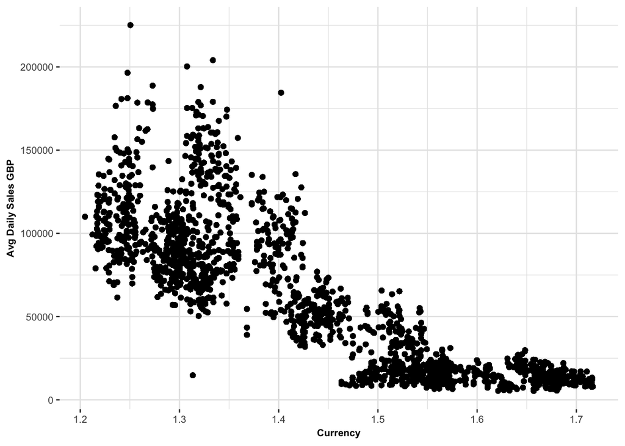

The next plot shows the relationship between Sales and how ‘unusual’ the temperature for a particular day was. This is done by using the remaineder element from the decomposition that was previously done on the daily weather values. The relationship does not seem strong, however it is possible to see that the highest sales numbers tend to lean towards to coldest days.

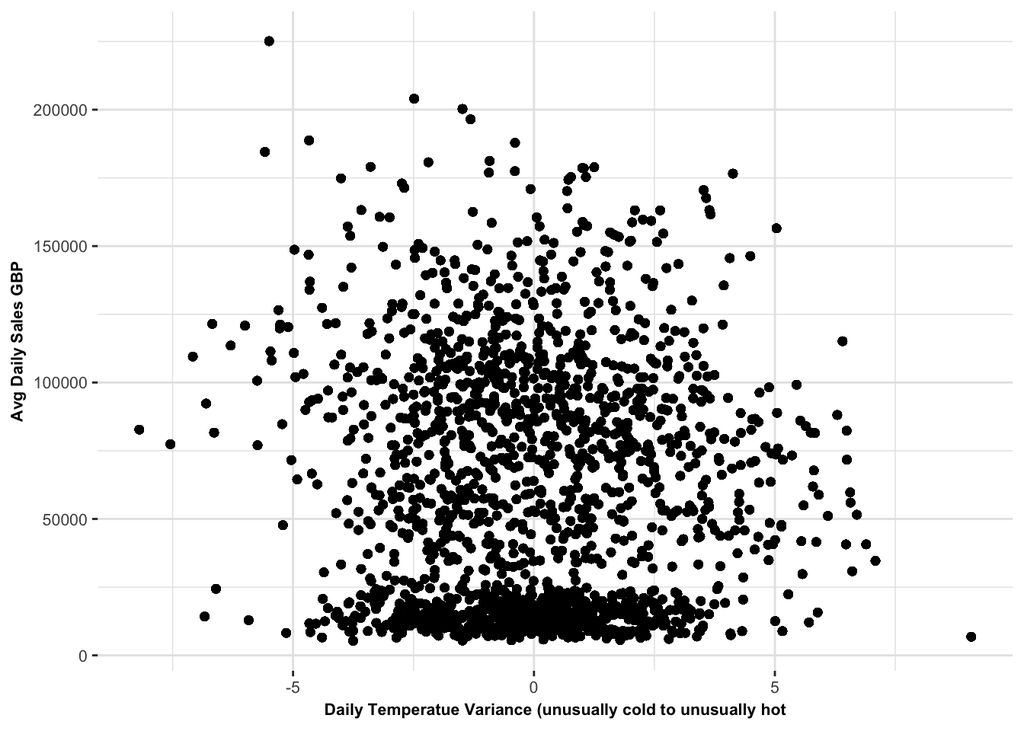

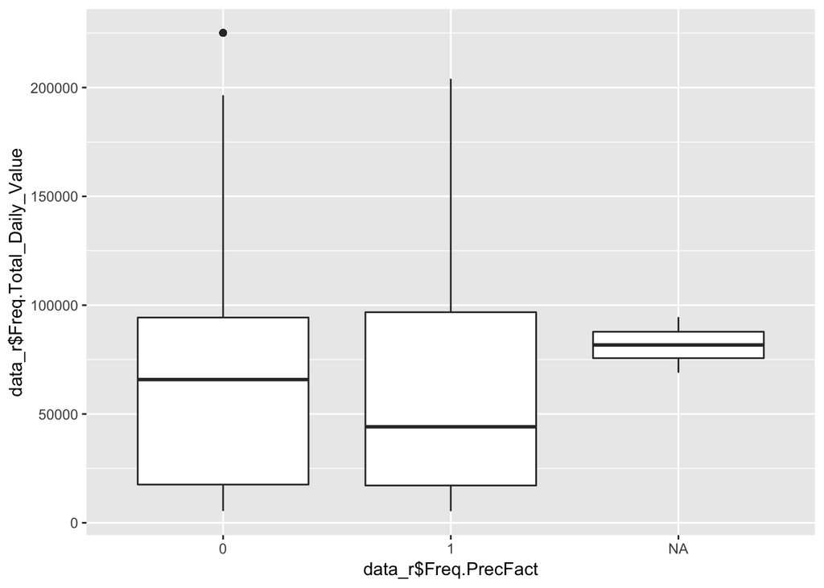

```r
#Precipitation close-up - needs ordering
ggplot(data_r, aes( data_r$Freq.PrecFact, data_r$Freq.Total_Daily_Value)) +
geom_boxplot()
```

```r
N <- nrow(data_r) # number of observations

window <- N / 365.25 # number of periods in the train set
require(data.table)
require(mgcv)
#weekday and month of the year effect
matrix_gam <- data.table(Sales = data_r[ ,"Freq.Total_Daily_Value" ],
                         Monthly = data_r[,"Freq.MonthNum"],
                        Weekly = data_r[,"Freq.WeekNum" ],
                        Temp = data_r[,"Freq.Remainder.y"],
                        price = data_r[,"Freq.Price" ],
                        trend = data_r[,"Freq.Trend.x"]
                       )



#individual gams on Day Of The Week and Month of The Year only, for visualisation of its effects
gam_1 <- gam(Sales ~ s(Weekly, bs = "ps", k = week_period) +
               s(Monthly, bs = "cr", k = 12),

             data = matrix_gam,
             family = gaussian)
```

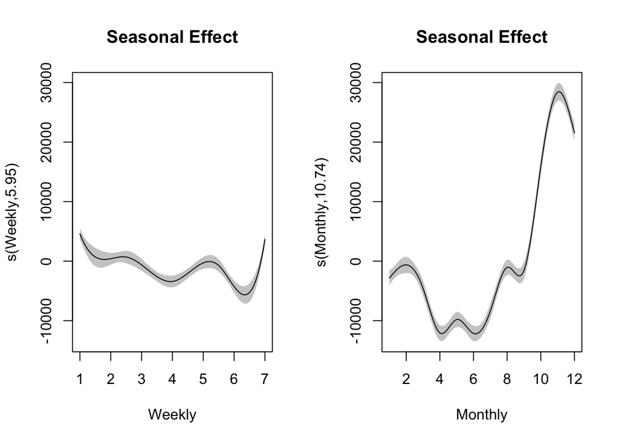

```r
#gam with week and month only

gam_0 <- gam(Sales ~ s(Weekly, Monthly),
             data = matrix_gam,
             family = gaussian)

#gam with monthly and trend

gam_2 <- gam(Sales ~ s(Weekly, Monthly, trend ),
             data = matrix_gam,
             family = gaussian)

#gam with all main variables
gam_3 <- gam(Sales ~ s(Weekly, Monthly, Temp, trend),
             data = matrix_gam,
             family = gaussian)

gam_4 <- gam(Sales ~ s(Weekly, Monthly, price, trend),
             data = matrix_gam,
             family = gaussian)

gam_5 <- gam(Sales ~ s(Weekly, Monthly, Temp, price, trend),
             data = matrix_gam,
             family = gaussian)

gam_6 <- gam(Sales ~ s(Weekly, Monthly, price),
             data = matrix_gam,
             family = gaussian)

gam_7 <- gam(Sales ~ s(Weekly, Monthly, Temp),
             data = matrix_gam,
             family = gaussian)
```

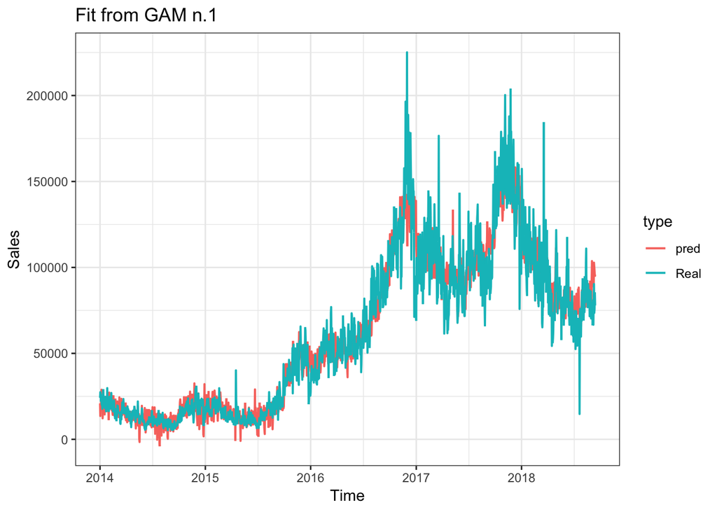

```r
summary(gam_0)$s.table
```

```
##                        edf   Ref.df       F p-value
## s(Weekly,Monthly) 28.22326 28.96195 131.952       0
```

```r
cat("GAM 0 R-sq:", summary(gam_0)$r.sq,"\n")
```

```
## GAM 0 R-sq: 0.07865049
```

```r
summary(gam_1)$s.table
```

```
##                  edf    Ref.df         F      p-value
## s(Weekly)   5.952275  5.998726  36.92548 4.127713e-45
## s(Monthly) 10.744591 10.985822 330.71625 0.000000e+00
```

```r
cat("GAM 1 R-sq:", summary(gam_1)$r.sq,"\n")
```

```
## GAM 1 R-sq: 0.07933767
```

```r
summary(gam_2)$s.table
```

```
##                             edf   Ref.df       F p-value
## s(Weekly,Monthly,trend) 108.041 108.9835 5320.08       0
```

```r
cat("GAM 2 R-sq:", summary(gam_2)$r.sq,"\n")
```

```
## GAM 2 R-sq: 0.9285065
```

```r
summary(gam_3)$s.table
```

```
##                                   edf   Ref.df        F p-value
## s(Weekly,Monthly,Temp,trend) 113.3189 113.9929 4844.079       0
```

```r
cat("GAMA 3 R-sq:", summary(gam_3)$r.sq,"\n")
```

```
## GAMA 3 R-sq: 0.9251999
```

```r
summary(gam_4)$s.table
```

```
##                                    edf   Ref.df        F p-value
## s(Weekly,Monthly,price,trend) 112.8698 113.9804 4855.096       0
```

```r
cat("GAM 4 R-sq:", summary(gam_4)$r.sq,"\n")
```

```
## GAM 4 R-sq: 0.9253504
```

```r
summary(gam_5)$s.table
```

```
##                                         edf   Ref.df        F p-value
## s(Weekly,Monthly,Temp,price,trend) 154.0224 154.9843 3748.769       0
```

```r
cat("GAM 5 R-sq:", summary(gam_5)$r.sq,"\n")
```

```
## GAM 5 R-sq: 0.9286377
```

```r
summary(gam_6)$s.table
```

```
##                              edf   Ref.df        F p-value
## s(Weekly,Monthly,price) 106.9641 108.9097 1528.855       0
```

```r
cat("GAM 6 R-sq:", summary(gam_6)$r.sq,"\n")
```

```
## GAM 6 R-sq: 0.788535
```

```r
summary(gam_7)$s.table
```

```
##                             edf   Ref.df        F p-value
## s(Weekly,Monthly,Temp) 106.9359 108.9248 76.08575       0
```

```r
cat("GAM 7 R-sq:", summary(gam_7)$r.sq)
```

```
## GAM 7 R-sq: 0.1559714
```

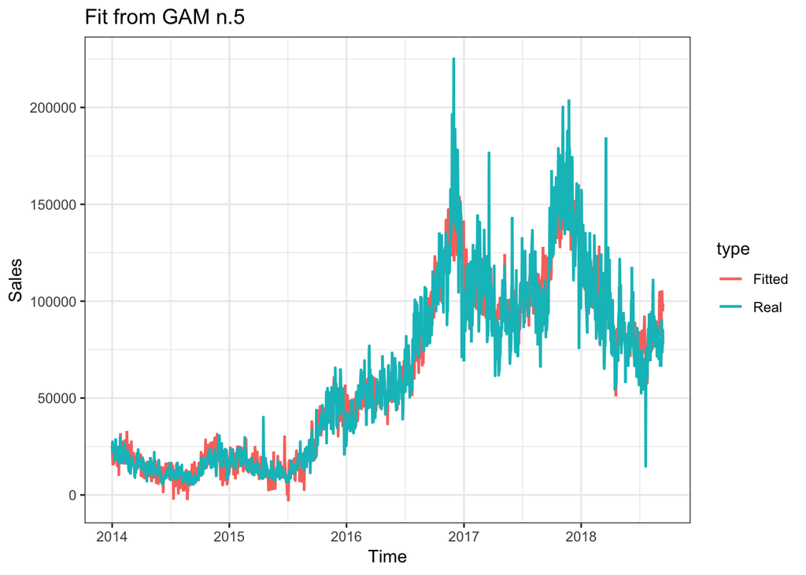

# Plotting sales values and fx

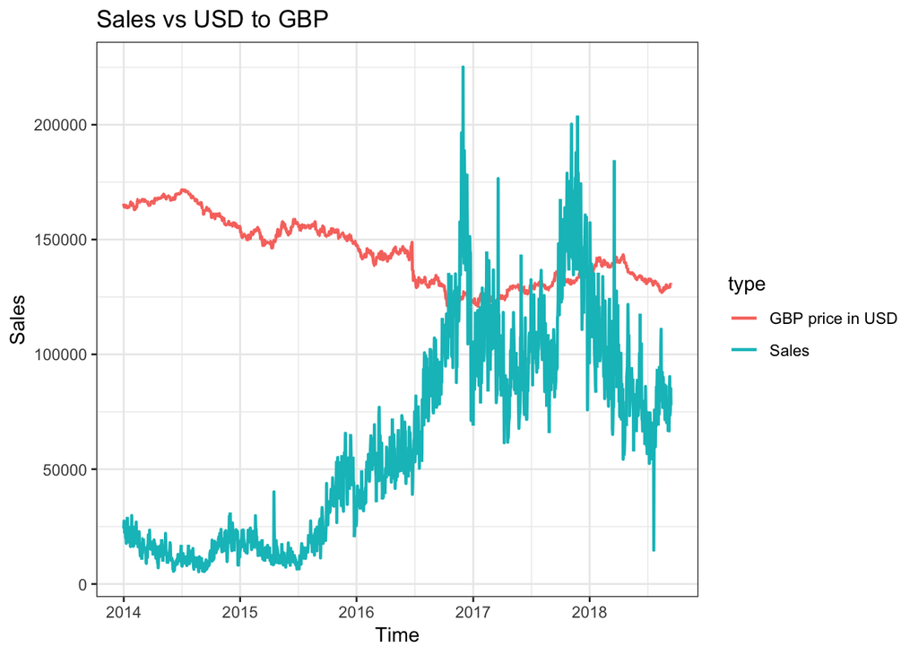

#Plotting sales values and weather

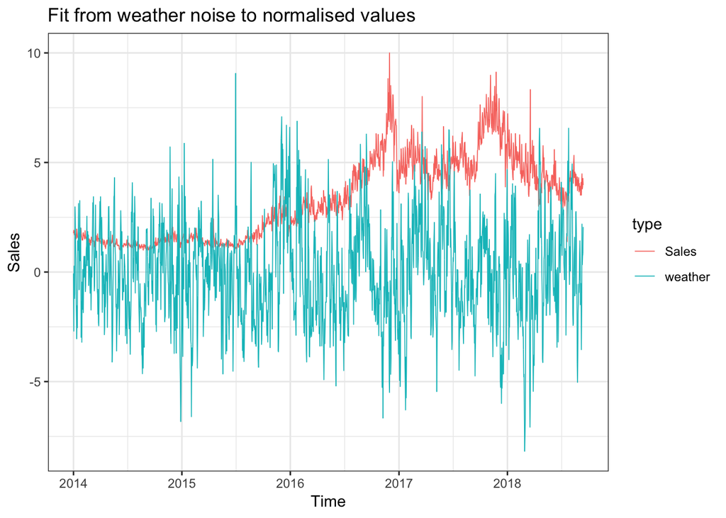

# for the future, could add:

# support for multiple currencies

# support for visualization of (value of sale in currency selected)

# prediction of values based on decomposed data + currency value by user input